# CanvasXpress: Stacked Chart

[figure not shown]

Bubble

Chord

[figure not shown]

Circular

Contour

Correlation

Dashboard

Density

Donnut

DotLine

Dotplot

[figure not shown]

Facet

Fish

Functions

Gantt

Genome

Heatmap

Hexplot-Binplot

Histogram

Kaplan-Meier

[figure not shown]

Layout

Line

Linear-Fit

Lollipop

Map

Meter

Network

NonLinear-Fit

[figure not shown]

Oncoprint

[figure not shown]

ParallelCoordinates

Pie

Radar

Remote-Graphs

Ridge-Line

[figure not shown]

SPLOM

Sankey

Scatter2D

Scatter3D

ScatterBubble2D

Stacked

StackedLine

StackedPercent

[figure not shown]

StackedPercentLine

Streamgraph

Sunburst

TCGA

[figure not shown]

TagCloud

Tree

Treemap

[figure not shown]

UpSet

Venn

Violin

## Stacked Chart

A barplot shows the relationship between a numeric and a categoric variable. Each entity of the categoric variable is represented as a bar. The size of the bar represents its numeric value. Barplot is sometimes described as a boring way to visualize information. However it is probably the most efficient way to show this kind of data. Ordering bars and providing good annotation are often necessary.

Example Fonts

[interactive chart not shown]

Tools

**HTML / JS**

```javascript
<!-- Include the CanvasXpress library in your HTML file -->
<link rel="stylesheet" href="https://www.canvasxpress.org/dist/canvasXpress.css" type="text/css"/>
<script src="https://www.canvasxpress.org/canvasXpress.min.js"></script>


<!-- Create a canvas element for the chart with the desired dimensions -->
<div>
  <canvas id="canvasId" width="600" height="600"</canvas>
</div>


<!-- Create a script to initialize the chart -->
<script>

  <!-- Create the data for the graph -->
  var data = {
     "x" : {
        "Factor1" : ["F1-A","F1-A","F1-A","F1-A","F1-A","F1-A","F1-A","F1-A","F1-B","F1-B","F1-B","F1-B","F1-B","F1-B","F1-B","F1-B","F1-C","F1-C","F1-C","F1-C","F1-C","F1-C","F1-C","F1-C"],
        "Factor2" : ["F2-a","F2-a","F2-a","F2-a","F2-b","F2-b","F2-b","F2-b","F2-c","F2-c","F2-c","F2-c","F2-d","F2-d","F2-d","F2-d","F2-e","F2-e","F2-e","F2-e","F2-f","F2-f","F2-f","F2-f"],
        "Factor3" : ["F3-i","F3-i","F3-j","F3-j","F3-k","F3-k","F3-l","F3-l","F3-m","F3-m","F3-n","F3-n","F3-o","F3-o","F3-p","F3-p","F3-q","F3-q","F3-r","F3-r","F3-s","F3-s","F3-t","F3-t"],
        "Factor4" : ["F4-a","F4-a","F4-a","F4-a","F4-b","F4-b","F4-b","F4-b","F4-a","F4-a","F4-a","F4-a","F4-b","F4-b","F4-b","F4-b","F4-a","F4-a","F4-a","F4-a","F4-b","F4-b","F4-b","F4-b"],
        "Factor5" : ["F5-a","F5-b","F5-c","F5-d","F5-e","F5-f","F5-g","F5-h","F5-i","F5-j","F5-k","F5-l","F5-m","F5-n","F5-o","F5-p","F5-q","F5-r","F5-s","F5-t","F5-u","F5-v","F5-w","F5-x"],
        "Factor6" : [1,2,3,4,5,6,7,8,8,7,6,5,4,3,2,1,1,2,3,4,5,6,7,8]
     },
     "y" : {
        "data" : [
          [2,4,6,8,3,5,7,9,2,4,6,8,3,5,7,9,3,5,7,9,4,6,8,10],
          [4,6,8,10,3,5,7,9,2,4,6,8,1,3,5,7,2,4,6,8,3,5,7,9],
          [3,5,7,9,4,6,8,10,3,5,7,9,2,4,6,8,4,6,8,10,3,5,7,9]
        ],
        "smps" : ["Smp1","Smp2","Smp3","Smp4","Smp5","Smp6","Smp7","Smp8","Smp9","Smp10","Smp11","Smp12","Smp13","Smp14","Smp15","Smp16","Smp17","Smp18","Smp19","Smp20","Smp21","Smp22","Smp23","Smp24"],
        "vars" : ["Var1","Var2","Var3"]
     }
  }


  <-- Create the configuration for the graph -->
  var config = {
     "colorScheme":"Blues",
     "foreground":"rgb(0,0,0)",
     "graphOrientation":"vertical",
     "graphType":"Stacked",
     "groupingFactors":[
        "Factor1"
     ],
     "legendKeyBackgroundBorderColor":"rgba(255,255,255,0)",
     "legendKeyBackgroundColor":"rgba(255,255,255,0)",
     "objectBorderColor":"rgb(0,0,0)",
     "sampleSpaceFactor":"1",
     "showTransition":"false",
     "title":"Random Data",
     "treemapBy":[
        "Factor2",
        "Factor3"
     ]
  }


  <!-- Call the CanvasXpress function to create the graph -->
  var cX = new CanvasXpress("canvasId", data, config);


</script>
```

**R Code**

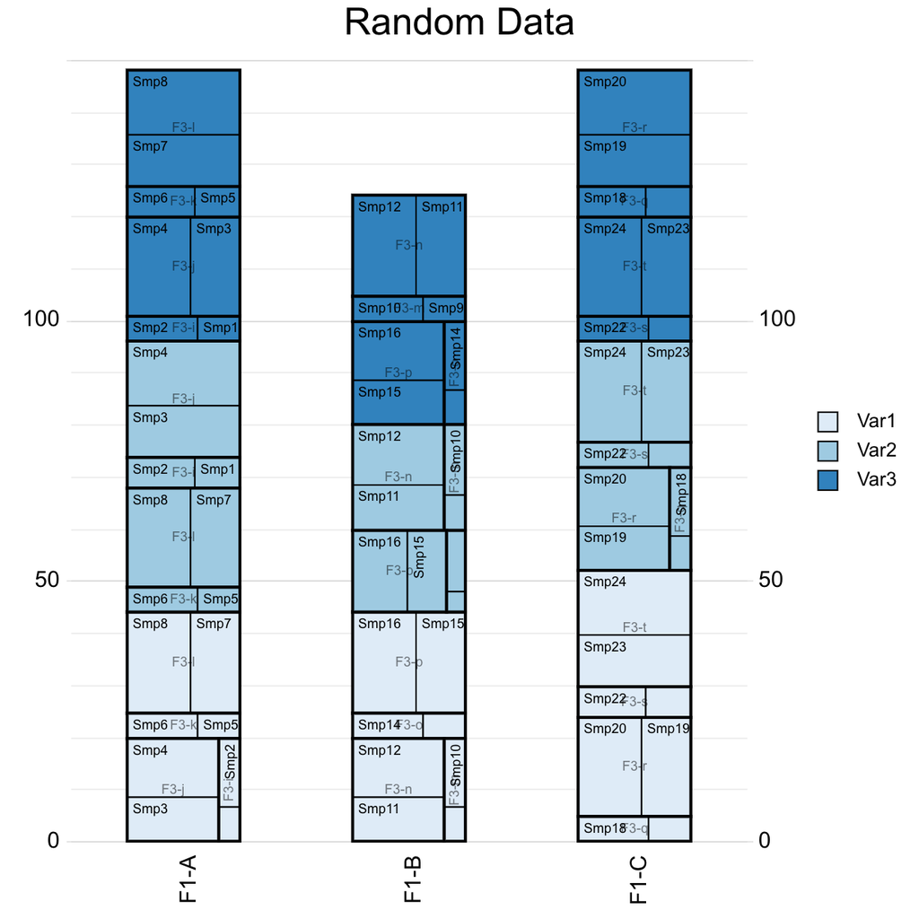

[figure not shown]

[figure not shown]

[figure not shown]

[figure not shown]

```r
library(canvasXpress)
y=read.table("https://www.canvasxpress.org/data/cX-stacked2-dat.txt", header=TRUE, sep="\t", quote="", row.names=1, fill=TRUE, check.names=FALSE, stringsAsFactors=FALSE)
x=read.table("https://www.canvasxpress.org/data/cX-stacked2-smp.txt", header=TRUE, sep="\t", quote="", row.names=1, fill=TRUE, check.names=FALSE, stringsAsFactors=FALSE)
canvasXpress(
  data=y,
  smpAnnot=x,
  colorScheme="Blues",
  foreground="rgb(0,0,0)",
  graphOrientation="vertical",
  graphType="Stacked",
  groupingFactors=list("Factor1"),
  legendKeyBackgroundBorderColor="rgba(255,255,255,0)",
  legendKeyBackgroundColor="rgba(255,255,255,0)",
  objectBorderColor="rgb(0,0,0)",
  sampleSpaceFactor=1,
  showTransition=FALSE,
  title="Random Data",
  treemapBy=list("Factor2", "Factor3")
)
```

⇧